# Diplomado Econometría Modulo IV: Modelos de Datos de Panel Dinámico

Universidad Nacional Autónoma de México (UNAM)  
Facultad de Economía

Mtro. Diego Sánchez Rojas

#### Sección 3: Modelos Dinámicos de Datos Panel

**3.1 Método de estimación VI y GMM**

**3.2 Método Arellano y Bond**

**3.3 Método Arellano y Boyer**

**3.4 Aplicaciones**

#### Modelos Dinámicos de Datos Panel (Método de estimación VI y GMM)

**¿Por qué utilizar los Modelos Dinámicos de Datos Panel?**

En los modelos de datos de panel estático suponemos que los errores idiosincráticos no están correlacionados a través de los períodos de tiempo.

- Supuesto de exogeneidad estricta, $\mathbf{E}(\mathbf{u}_i \mid \mathbf{x}_i, c_i) = 0$
- y por tanto, no correlación serial.: $~~E(u_{it}, u_{is}) = 0 ~~t\neq s$
- Cuando estos supuestos fallan provocan que los estimadores sean inconsistentes, **problema de endogeneidad**

#### Modelos Dinámicos de Datos Panel (Método de estimación VI y GMM)

**¿Cómo solucinarlo?**

- Podremos utilizar valores de variables explicativas en otros períodos ($X_{t-1}$) como instrumentos válidos de las $X_t$.
- En los modelo dinámicos se toma en cuenta la dependecia temporal.
- Ejemplos:
  - Modelos de demanda de factores: Nivel de empleo y salarios actuales probablemente dependan de sus niveles pasados
  - Ecuaciones de consumo de los hogares: persistencia en el tiempo
  - Modelos empíricos de crecimiento económico:El PIB per cápita actual depende del PIB per cápita pasado (convergencia o divergencia).

#### Modelos Dinámicos de Datos Panel (Método de estimación VI y GMM)

**¿Qué es un instrumento?**

- Un instrumento es una variable que usamos para resolver el problema de endogeneidad en un modelo de regresión.
- Un instrumento funciona como una fuente externa de variación “limpia” para identificar el efecto causal.

#### Modelos Dinámicos de Datos Panel (Método de estimación VI y GMM)

**Recordando: Método Variables Instrumentales**

- Consideremos el modelo de regresión: $y_i = \beta_0 + \beta_1x_i + u_i$
- Donde existe endogeneidad: $Cov(x_i, u_i) \neq 0$

#### Modelos Dinámicos de Datos Panel (Método de estimación VI y GMM)

- En el caso de modelos panel

$$y_{it}= \textbf{x}_{it}\boldsymbol{\beta} + u_{it} ~~~t=1,2,...T$$

- **Endogeneidad**: $E(\textbf{x}_{it}'u_{it}) \neq 0$
- Correlación serial:

  $E(u_{it}u_{is})\neq 0s~~~t,s=1,2,...t,s$

#### Modelos Dinámicos de Datos Panel (Método de estimación VI y GMM)

**Recordando: Método Variables Instrumentales**

Un instrumento válido $z$ debe cumplir dos condiciones:

- **Relevancia**: Correlación alta con variable endógena
  $$Cov(z_i, x_i) \neq 0$$
- **Exogeneidad**: No correlación con el error
  $$Cov(z_i,u_i) = 0$$
- **Exclusión**: El instrumento $z$ solo puede afectar a $y$ a través de su efecto en la variable endógena $x$

#### Modelos Dinámicos de Datos Panel

**Recordando: Variables Instrumentales**

El estimador VI se obtiene en dos etapas.

Primera Etapa:
$$x_i = \pi_0 + \pi_1Z_i + \epsilon_i$$

Segunda Etapa:

$$y_i = \beta_0 + \beta_1\hat{x_i} + u_i$$

Estimador VI en caso de un solo instrumento:

$$\hat{\beta}_{VI} = (\mathbf{z}'\mathbf{\hat{x}})^{-1}\mathbf{z}'\mathbf{y}$$

#### Modelos Dinámicos de Datos Panel

**Intuición**

- **Etapa 1:** filtramos $X$ con $Z$.
- **Etapa 2:** usamos solo la parte “limpia” $\hat{X}$ para estimar el coeficiente de interpes en la seguna etapa

#### Modelos Dinámicos de Datos Panel

- Resuelven el **problema de endogeneidad**.
- Necesitan **instrumentos válidos**:
  - **Relevancia**: correlacionados con la variable endógena.
  - **Exogeneidad**: no correlacionados con el error.
- Estimación en **dos etapas (2SLS)**:
  1. Filtrar la variable endógena con los instrumentos.
  2. Estimar el modelo con la parte “limpia”.
- Permiten **identificar relaciones causales** aun cuando OLS está sesgado.
- Limitación: **difícil encontrar instrumentos buenos** → riesgo de instrumentos débiles.

#### Modelos Dinámicos de Datos Panel (Método de estimación VI y GMM)

**Recordando el método de momentos (MM)**

- Técnica que permite estimar parámetros solucionando las condiciones del momento muestral que corresponden al momento poblacional.
- Por ejemplo, queremos estimar la media poblacional ($\mu$) de una caráterística ($y$) que $iid$, utilizando el operador de expectativas:

$$E[y -\mu] = 0$$

- Vamos a remplazar el operador de expectativas para la población $E(.)$ por el operador muestral:

$$\frac{1}{N} \sum_{i=1}^{N} (y_i - \mu) = 0$$

#### Modelos Dinámicos de Datos Panel (Método de estimación VI y GMM)

##### Recordando: Utilizando el método de momentos (MM)

- Despejando para $\mu$:

$$\hat{\mu}_{\text{MM}} = N^{-1} \sum_i y_i = \bar{y}$$

- Tendremos que el estimador **MM** de la media poblacional es la media muestral.

#### Modelos Dinámicos de Datos Panel (Método de estimación VI y GMM)

Lo llevamo a un modelo de regresión lineal:

$$y = \mathbf{x}'\beta + u$$

- Supuesto de exogeneidad no condicional $E[\mathbf{x}'u] = 0$

Es decir, K condiciones de momentos no condicionales $E[\mathbf{x}'u] = 0$.

#### Modelos Dinámicos de Datos Panel (Método de estimación VI y GMM)

- Por ese supuesto de exogeneidad y el operador de expectativas para la población:

$$E[\mathbf{x}'(y - \mathbf{x}\beta)] = 0$$

- Reemplazamos por el operador muestral:

$$\frac{1}{N} \sum_{i=1}^{N}\mathbf{x}_i'(y_i - \mathbf{x}_i\beta) = 0$$

#### Modelos Dinámicos de Datos Panel (Método de estimación VI y GMM)

- Resolvemos para $\beta$ tendremos :

$$\hat{\beta}_{\text{MM}} = (\sum_i \mathbf{x}_i'\mathbf{x}_i)^{-1} \sum_i \mathbf{x}_i'y_i$$

- Supuesto media condicional cero, es decir que los regresores (explicativas) son ortogonales al error y el **Estimador de MM será consistente**.

#### Modelos Dinámicos de Datos Panel (Método de estimación VI y GMM)

**Utilizando el MM para VI**

- Tendremos que alguna de las $\mathbf{x}$ son endógenas, es decir, algunos componentes de $\mathbf{x}$ están correlacionadas con los términos de error $u$.
- $E[\mathbf{x}'u] = 0$ no se cumple y por lo tanto $\beta_{MM}$ no será consistente
- Asumiremos que existen los intrumentos $z$ que están correlacionados con $\mathbf{x}$ y que satisfacen:

$E[u|\mathbf{z}] = 0$

#### Modelos Dinámicos de Datos Panel (Método de estimación VI y GMM)

- Suponemos que tenemos un vector de instrumentos y se satisface que $E[u|\mathbf{z}] = 0$ (exógenos), podemos obtenemos las K condiciones de momentos no condicionales poblaciones :

$$E[\mathbf{z}(y - \mathbf{x}'\beta)] = 0$$

#### Modelos Dinámicos de Datos Panel (Método de estimación VI y GMM)

- El estimador MM soluciona el respectivo momento muestral:

$$\frac{1}{N} \sum_{i=1}^{N}\mathbf{z}_i(y_i - \mathbf{x}_i'\beta) = 0$$

#### Modelos Dinámicos de Datos Panel (Método de estimación VI y GMM)

Si $dim(\mathbf{z})=K$:

- Despejando para $\beta$$ :

$$\hat{\beta}_{\text{MM}} = ( \sum_{i}^{N} \mathbf{z}_i\mathbf{x}_i')^{-1} \sum_{i} \mathbf{z}_iy_i$$

- Obtenemos el estimador lineal IV, el cual es consistente.

#### Modelos Dinámicos de Datos Panel (Método de estimación VI y GMM)

**Método de Generalizado de Momentos (GMM)**

En GMM se utiliza cuando tendremos diferentes tipos de condiciones de momentos.

- En MM para el estimador linear VI suponemos que $E[u|\mathbf{z}] = 0$ por tanto teníamos condiciones de momentos no condicionales o momentos de ortogonalidad:

$$E[z_i(y_i - x_i'\beta)] = 0$$

- Pero para el supuesto de homocedasticidad $E[u^2|\mathbf{z}] =\sigma^2$ , tendremos condiciones de momento de orden superior:

$$E[z_i(y_i - x_i'\beta)^2] = 0$$

- O cuando tenemos Datos Panel en donde los rezagos pueden ser instrumentos, tendremos condiciones specíficas para cada período, es decir un vector de **r funciones de momentos**:

$$E[z_{it}(y_{it} - x_{it}'\beta - \alpha_i)] = 0$$

#### Modelos Dinámicos de Datos Panel (Método de estimación VI y GMM)

##### Recordando: Método de Generalizado de Momentos (GMM)

- El GMM se basa en $r$ condiciones de momentos poblacionales para q parámetros:

$$E[\mathbf{h}(\mathbf{w_i},\theta_{0})] = 0$$

Donde:

- $\theta$ vector de $q~~x~~1$ parámetros a estimar
- $\mathbf{h}(.)$ : vector de r funciones de momentos
- $\mathbf{w}$ : conjunto completo de observables. Incluye las variables $\mathbf{y}$, $\mathbf{x}$ y $\mathbf{z}$

#### Modelos Dinámicos de Datos Panel (Método de estimación VI y GMM)

**Método de Generalizado de Momentos (GMM)**

- Si r=q podremos aplicar el MM Condiciones de momentos muestrales.
- La igualdad a cero del momento poblacional se sustituye por la igualdad a cero del momento muestral correspondiente, y el estimador de MM $\mathbf{\hat{\theta}_{MM}}$ será definido para ser la solución:

$$\frac{1}{N} \sum_{i=1}^N \mathbf{h}(\mathbf{w_i}, \mathbf{\hat{\theta}}) = 0$$

#### Modelos Dinámicos de Datos Panel (Método de estimación VI y GMM)

Para encontrar la solución tendremos que minimizar la función objetivo respecto a $\theta$:

$$Q_N(\theta) = \left[\frac{1}{N} \sum_{i=1}^N \text{h}(\mathbf{w_i}, \theta)\right]' \left[\frac{1}{N} \sum_{i=1}^N \text{h}(\mathbf{w_i}, \theta)\right]$$

- Por tanto, calcularemos la derivada pacial:

$$\frac{\partial Q_N(\theta)}{\partial \theta} = 0$$

#### Modelos Dinámicos de Datos Panel (Método de estimación VI y GMM)

**Regresando al caso de VI**

- Para el caso de VI donde tenemos multiples instrumentos:

$$E[\mathbf{z}_i(y_i - \mathbf{x}_i'\beta)] = 0$$

- Cada instrumento generará una condición de momentos:

$$\ H(.) = \begin{pmatrix}
z_{1i}(y_i - x_i'\beta) \\
z_{2i}(y_i - x_i'\beta) \\
\vdots \\
z_{ri}(y_i - x_i'\beta)
\end{pmatrix}$$

#### Modelos Dinámicos de Datos Panel (Método de estimación VI y GMM)

- **En este caso si** $r=q$ decimos que el modelo está exactamente identificado y el MM podrá utilizarse:

$$\mathbf{\hat{\theta}_{\text{MM}}} = ( \sum_{i}^{N} \mathbf{z}_i\mathbf{x}_i')^{-1} \sum_{i} \mathbf{z}_iy_i$$

#### Modelos Dinámicos de Datos Panel (Método de estimación VI y GMM)

- Ejemplo de la identificación exacta (r=q):
  - Tenemos dos variables endógenas (k=2)
  - Necesitaremos dos intrumentos (r=2)
  - y estimaremos dos parámetros (q=2)
  - $\therefore$ El sistema está identificado
- Implicaciones de la identificación exacta (r=q):
  - Solución única
  - El estimador MM podrá utilizarse y concidé con el estimador GMM
  - No permite pruebas de sobreidentificación
  - Estimador menos eficiente

#### Modelos Dinámicos de Datos Panel (Método de estimación VI y GMM)

##### Recordando: Método de Generalizado de Momentos (GMM)

**¿Qué pasa cuando** $r>q$?

- Existen más instrumentos ($r_i$) que variables endógenas, tendremos por tanto más condiciones de momentos $h_{j}(.)$ que parámetros a estimar ($q_i$).
- Por tanto tenemos el modelo está **sobreidentificado**.
- No hay solución única para $\mathbf{\hat{\theta}}$.

#### Modelos Dinámicos de Datos Panel: Método de Generalizado de Momentos (GMM) (Estimación)

##### Recordando: Método de Generalizado de Momentos (GMM)

- En este caso el estimador
  $$\mathbf{\hat{\theta}_{GMM}}$$
  con base en las condiciones de momentos es el que minimiza la función objetivo en su versión cuadrática:

$$Q_N(\theta) = \left[\frac{1}{N} \sum_{i=1}^N \text{h}(\text{w}_{i}, \theta)\right]' \mathbf{W_{N}} \left[\frac{1}{N} \sum_{i=1}^N \text{h}(\text{w}_{i}, \theta)\right]$$

Donde:

- $\mathbf{W_{N}}$ es una matriz de pesos de dimensión $r~x~r$, simétrica, definida positiva y no depende de $\theta$

#### Modelos Dinámicos de Datos Panel: Método de Generalizado de Momentos (GMM) (Estimación)

Simplificando la notación tendremos:

$y = \mathbf{X}\beta + u$

y las condiciones de momento (matriz de instrumentos): $\sum_i z_i (y_i - \mathbf{x}_i'\beta) = \mathbf{Z}'u$

de forma matricial la función objetivo GMM $Q_N(\beta)$:

$$Q_N(\beta) = \left[\frac{1}{N} (\mathbf{y}-\mathbf{X}\beta)'\mathbf{Z}\right] \mathbf{W_{N}} \left[\frac{1}{N} \mathbf{Z}'(\mathbf{y}-\mathbf{X}\beta)\right]$$

#### Modelos Dinámicos de Datos Panel: Método de Generalizado de Momentos (GMM) (Estimación)

- Donde $\mathbf{W}_N$ es una matriz de $r$ x $r$

Las condiciones de primer orden serán:

$$\frac{\partial Q_N(\beta)}{\partial \beta} = -2\left[\frac{1}{N} \mathbf{X}'\mathbf{Z}\right] \mathbf{W_{N}} \left[\frac{1}{N} \mathbf{Z}'(\mathbf{y}-\mathbf{X}\beta)\right]=0$$

#### Modelos Dinámicos de Datos Panel: Método de Generalizado de Momentos (GMM) (Estimación)

- La condiciones de primer orden pueden ser resultar para $\beta$:

$$\hat\beta_{GMM} = \left[ \mathbf{X}'\mathbf{Z}\mathbf{W_N}\mathbf{Z}'\mathbf{X}\right]^{-1}\mathbf{X}'\mathbf{Z}\mathbf{W_N}\mathbf{Z}'\mathbf{y}$$

- **Estimador GMM de modelo lineal de variables instrumentales**

#### Modelos Dinámicos de Datos Panel: Método de Generalizado de Momentos (GMM) (Estimación)

**Intuición de la matriz** $W$

- Es una matriz de pesos de dimensión $r~x~r$ donde r es el número de instrumentos.

Sirve para ponderar las condiciones de momento:

2 instrumentos:

- $z_1$ muy confiable y $z_2$ un poco más ruidoso
- Si simplemente sumamos las violaciones de las condiciones de momento sin ponderar, puede afectar demasiado la estimación.

Te permite darle más peso a instrumentos confiables y menos peso a los ruidosos.

#### Modelos Dinámicos de Datos Panel: GMM con datos Panel

- Regresamos a los **MODELOS de DATOS PANEL**
- Consideraciones:
  - Relajación o flexibilización del supuesto de **exogeneidad estricta**, por tanto tendremos modelos consistentes con variables endógenos o rezagos de la variable dependiente como regresores.
  - El uso de VI es una alternativa para resolver o manejar el **problema de edogeneidad**.
  - En datos panel es más sencillo aplicar VI porque podemos utilizar **rezagos de las variables explicativas exógenas como instrumentos** de las variables endógenas del período actual.
  - Adicionalmente, podemos utilizar los rezagos de la **variable dependiente como instrumentos**.

#### Modelos Dinámicos de Datos Panel (Método de estimación VI y GMM)

##### Método de Generalizado de Momentos (GMM) con datos Panel

- Modelo lineal de datos panel:

$$y_{it}= \textbf{x}_{it}'\boldsymbol{\beta} + u_{it}$$

- Notemos que no consideramos el efecto individual no observado $c_{i}$ por la relajación del supuesto de exogeneidad
- Suponemos que las observaciones son independientes entre individuos y tenemos $T$ períodos de tiempo fijos

#### Modelos Dinámicos de Datos Panel (Método de estimación VI y GMM)

##### Método de Generalizado de Momentos (GMM) con datos Panel

- Por notación, con todos lo períodos apilados tendremos el siguiente sistema de ecuaciones:

$$\mathbf{y_{i}} = \textbf{X}_{i}\boldsymbol{\beta} + \mathbf{u_{it}}$$

Donde $\mathbf{y_{i}}$ y $\mathbf{u_{it}}$ son vectores de $1~x~T$ y $\textbf{X}_{i}$ es una matriz de $T~x~K$ :

$$\mathbf{y}_i = \begin{bmatrix}
y_{i1} \\
\vdots \\
y_{iT}
\end{bmatrix}; \quad
\mathbf{X}_i = \begin{bmatrix}
\mathbf{x}'_{i1} \\
\vdots \\
\mathbf{x}'_{iT}
\end{bmatrix}; \quad
\mathbf{u}_i = \begin{bmatrix}
u_{i1} \\
\vdots \\
u_{iT}
\end{bmatrix}$$

#### Modelos Dinámicos de Datos Panel (Método de estimación VI y GMM)

##### Método de Generalizado de Momentos (GMM) con datos Panel

- Dado que permitimos endogeneidad y la utilización de rezagos (lags) ($\textbf{x}_{it-1}$) exógenos de las variables endógenas tendremos una matriz $\textbf{Z}_{i}$ de dimesiones $T~~x~~r$
- Donde $r\geq K$ es el número de instrumentos que satisfacen las $r$ condiciones de momentos:

$$E[\mathbf{Z}'\mathbf{u_{i}}] = \mathbf0$$

- Donde
  $$\mathbf{u_{i}} = \mathbf{y_i} - \textbf{X}\_{i}\beta$$

#### Modelos Dinámicos de Datos Panel (Método de estimación VI y GMM)

##### Método de Generalizado de Momentos (GMM) con datos Panel

- Tendremos que encontrar el estimador GMM que minimiza la función objetivo en su forma cuadrática:

$$Q_N(\beta) = [ \sum_{i=1}^N \mathbf{Z}'\mathbf{u_{i}} ]' \mathbf{W}_N [\sum_{i=1}^N \mathbf{Z}'\mathbf{u_i}]$$

- Donde:
- $\mathbf{W_{N}}$ es una matriz de pesos de dimensiones $r~x~r$, simétrica definida positiva y no depende de $\beta$

#### Modelos Dinámicos de Datos Panel (Método de estimación VI y GMM)

##### Método de Generalizado de Momentos (GMM) con datos Panel

- Después de realizar malabares algebraicos encontramos el estimador **GMM para datos panel** o **PGMM**

$$\hat{\beta}_{\text{PGMM}} =
\left[ \left( \sum_{i=1}^{N} \mathbf{X}_i' \mathbf{Z}_i \right)
\mathbf{W}_N \left( \sum_{i=1}^{N} \mathbf{Z}_i' \mathbf{X}_i \right) \right]^{-1}
\left( \sum_{i=1}^{N} \mathbf{X}_i' \mathbf{Z}_i \right)
\mathbf{W}_N \left( \sum_{i=1}^{N} \mathbf{Z}_i' \mathbf{y_i} \right).$$

- La condicional escencial para *PGMM* sea consistente es que la :

$$E[\mathbf{Z}'\mathbf{u_{i}}] = \mathbf0$$

#### Modelos Dinámicos de Datos Panel (Método de estimación VI y GMM)

##### Método de Generalizado de Momentos (GMM) con datos Panel (Consideraciones)

- ¿Qué pasa si todas las variables explicativas son exógenas?

$$E[\mathbf{x}_{it}u_{i}] = 0$$

- En ese caso:

$$\mathbf{Z_i} = [\mathbf{x}'_{i1},...\mathbf{x}'_{iT}]$$

- Por tanto:

$$\mathbf{Z_i} = \mathbf{X_i}$$

- El modelo estará identificado y estimador $\hat{\beta}_{\text{PGMM}}$ será un simple estimador $\hat{\beta}_{pols}$

#### Modelos Dinámicos de Datos Panel (Método de estimación VI y GMM)

##### Método de Generalizado de Momentos (GMM) con datos Panel (Consideraciones)

- Pero si asumimos que:

  $$E[\mathbf{x}_{it-1}u_{i}] = 0$$
- **Rezagos pueden servir como instrumentos válidos**.
- Por tanto tendremos instrumentos disponibles para las ith y el modelo está **sobre identificado**.
- Obtendremos estimadores eficientes con el estimador PGMM

#### Modelos Dinámicos de Datos Panel (Método de estimación VI y GMM)

##### Método de Generalizado de Momentos (GMM) con datos Panel (Consideraciones)

- En un modelo econométrico, decimos que hay sobreidentificación si:
  - Existen más instrumentos disponibles que restricciones necesarias para identificar los parámetros del modelo.
  - En términos simples, tenemos más información de la necesaria para estimar los parámetros del modelo.
- La sobreidentificación implica un equilibrio entre tener suficientes instrumentos para corregir la **endogeneidad** y no tantos como para crear problemas de **varianza** o invalidación de los supuestos.

#### Modelos Dinámicos de Datos Panel (Método de estimación VI y GMM)

Ejemplo:

- Supongamos una regresión simple con **un parámetro**:

  $$y_i = x_i \beta + u_i$$
- Tenemos **dos instrumentos**:

$z_{1i}, z_{2i}$

#### Modelos Dinámicos de Datos Panel (Método de estimación VI y GMM)

- En población:

$$E[z_{1i}(y_i - x_i \beta)] = 0$$

$$E[z_{2i}(y_i - x_i \beta)] = 0$$

- Son **2 restricciones** $r=2$ para **1 parámetro** $q=1$
- El sistema está **sobreidentificado** $r > q$

#### Modelos Dinámicos de Datos Panel (Método de estimación VI y GMM)

**Momentos Muestrales**

$$g_N(\beta) = \frac{1}{N}\sum_{i=1}^N
\begin{bmatrix}
z_{1i}(y_i - x_i\beta) \\
z_{2i}(y_i - x_i\beta)
\end{bmatrix}$$

La función objetivo será:

$$Q_N(\beta) \;=\; g_N(\beta)^{\prime}\, W_N\, g_N(\beta)$$

donde $W_N$ es una matriz $2\times 2$ simétrica definida positiva.

#### Modelos Dinámicos de Datos Panel (Método de estimación VI y GMM)

- Con **más instrumentos que parámetros** ($r > q$) el sistema está **sobreidentificado**.
- El estimador GMM combina todos los instrumentos usando la matriz de peso $W_N$.
- Intuición: si los instrumentos son válidos, las condiciones de momento “sobrantes” deberían cumplirse en promedio.

#### Modelos Dinámicos de Datos Panel (Método de estimación VI y GMM)

- **“Estimación Eficiente con Datos de Panel Cuando los Instrumentos Están Predeterminados: Una Comparación Empírica de los Estimadores de Condición de Momento” por James P. Ziliak**

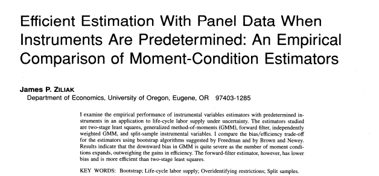

#### Modelos Dinámicos de Datos Panel (Método de estimación VI y GMM)

##### Método de Generalizado de Momentos (GMM) con datos Panel (Ejemplo)

- Relación salario y oferta laboral (horas de trabajo)
- El modelo estándar de la economía laboral sugiere que el efecto de un aumento salarial sobre la oferta de trabajo es ambiguo.
- **Efecto ingreso**: Un aumento en el salario puede llevar a una persona a trabajar menos horas, ya que ahora gana más y puede permitirse más tiempo libre.
- **Efecto sustitución**: Por otro lado, el mismo aumento salarial incentiva a trabajar más horas, ya que el costo de oportunidad del tiempo libre es mayor.

Estos dos efectos son opuestos: el efecto ingreso tiende a reducir el trabajo, mientras que el efecto sustitución lo incrementa. El resultado final dependerá de cuál de estos efectos sea más fuerte.

#### Modelos Dinámicos de Datos Panel (Método de estimación VI y GMM)

##### Método de Generalizado de Momentos (GMM) con datos Panel (Ejemplo)

- **Análisis de corte transversal**:
  - Los estudios de corte transversal (analizando datos de una sola observación por individuo) han encontrado una respuesta positiva, pero pequeña, de las horas trabajadas en respuesta a los salarios entre hombres adultos.
  - Sin embargo, esta relación podría no ser causal, sino más bien espuria. Es decir, podría deberse a variables no observadas que influyen tanto en las horas trabajadas como en los salarios. Por ejemplo, las personas con una mayor inclinación o preferencia por trabajar más horas podrían también buscar empleos mejor remunerados.
- **Análisis de datos de panel**:
  - Permite controlar estas características no observadas que son constantes en el tiempo para cada individuo.
  - El **“within estimator”** o estimador de efectos fijos compara las horas trabajadas y los salarios de un mismo individuo a lo largo del tiempo, eliminando así las características invariables del individuo (por ejemplo, su preferencia intrínseca por trabajar más).

#### Modelos Dinámicos de Datos Panel (Método de estimación VI y GMM)

##### Método de Generalizado de Momentos (GMM) con datos Panel (Ejemplo)

- MaCurdy (1981) desarrolló este modelo basándose en un marco teórico de oferta laboral durante el ciclo de vida bajo incertidumbre:

$$\text{lnhrs}_{it} = \alpha_i + \beta_1\text{lnwg}_{it} + \beta_2\text{kids}_{it} + \beta_3\text{age}_{it} + \beta_4\text{agesq}_{it} + \beta_5\text{disab}_{it} + u_{it}$$

- El concepto $\alpha$ es igual a $c_i$
- $\alpha_i$ es un multiplicador que representa la utilidad marginal de la riqueza inicial. Este multiplicador es constante en el tiempo (time-invariant). Pero varía entre individuos (differs across individuals)

#### Modelos Dinámicos de Datos Panel (Método de estimación VI y GMM)

##### Método de Generalizado de Momentos (GMM) con datos Panel (Ejemplo)

El desafío econométrico:

- Como $\alpha_i$ depende de variables y restricciones específicas de cada individuo. Como efecto fijo.
- Donde se tiene que cumplir el supuesto de **exogeneidad estricta**.

#### Modelos Dinámicos de Datos Panel (Método de estimación VI y GMM)

##### Método de Generalizado de Momentos (GMM) con datos Panel (Ejemplo)

- El problema identificado por Ziliak (1997):

  -Permite que logaritmo del salario esté correlacionado contemporáneamente con el termino de error. Esto puede ocurrir por dos razones:
  - 1. Error de medición en los salarios (measurement error in wage)
  - 2. Puntos de inflexión en la restricción presupuestaria
- La consecuencia:
  - El estimador de Mínimos Cuadrados Ordinarios (OLS) de la especificación del modelo anterior es inconsistente
- Solucionar endogeneidad por método de variables instrumentales

#### Modelos Dinámicos de Datos Panel (Método de estimación VI y GMM)

##### Método de Generalizado de Momentos (GMM) con datos Panel (Ejemplo)

La solución propuesta:

- Los instrumentos son rezagos (lags) de las variables regresoras
- Supuesto clave: los salarios pasados no están correlacionados con el error actual

Las condiciones:

$$E[\mathbf{lnwg}_{s}u_{it}] = 0$$

Donde:

- $\mathbf{lnwg}_t$ depende de $\mathbf{lnwg}_s$
- El término de error por construcción puede estar correlacionado.
- Esto significa que se pueden usar como instrumentos los rezagos de dos o más períodos
- Implicación práctica: Se necesitan al menos tres períodos de datos originales para identificar $\beta$

#### Modelos Dinámicos de Datos Panel (Método de estimación VI y GMM): Matriz W

Se escoge **un rezago** por variable endógena en cada período.

- Ejemplo: para $x_{it}$ con $x_{i,t-1}$, se usa $x_{i,t-2}$ como instrumento.

$$W = (Z'Z)^{-1}, \quad Z = \text{matriz de instrumentos}$$

#### Modelos Dinámicos de Datos Panel (Método de estimación VI y GMM): Matriz W

Construcción de $Z_i$ para un caso específico:

- 2 observaciones ($i=1,2$) y 3 períodos ($t = 3,4,5$) y que los valores $x$ son:

| Individuo | $x_1$ | $x_2$ | $x_3$ |
| --- | --- | --- | --- |
| 1 | 2 | 3 | 4 |
| 2 | 1 | 0 | 2 |

#### Modelos Dinámicos de Datos Panel (Método de estimación VI y GMM): Matriz W

Tendremos una matriz $Z_i$ para cada observación:

$$Z_i =
\begin{bmatrix}
x_{i1} & 0 & 0 \\
x_{i1} & x_{i2} & 0 \\
x_{i1} & x_{i2} & x_{i3}
\end{bmatrix}$$

#### Modelos Dinámicos de Datos Panel (Método de estimación VI y GMM): Matriz W

En este ejemplo como tenemos dos observaciones:

- Para $i=1$:

$$Z_1 =\begin{bmatrix}
2 & 0 & 0 \\
2 & 3 & 0 \\
2 & 3 & 4
\end{bmatrix}$$

- Para $i=2$:

$$Z_2 =
\begin{bmatrix}
1 & 0 & 0 \\
1 & 0 & 0 \\
1 & 0 & 2
\end{bmatrix}$$

#### Modelos Dinámicos de Datos Panel (Método de estimación VI y GMM): Matriz W

Si observamos:

- Para $t=3$ solo se puede usar $x_{t-2} = x_1$ con instrumento
- Para $t=4$ solo se puede usar $ x_1, x_2$ con instrumentos
- Para $t=5$ solo se puede usar $x_1, x_2,x_3$ con instrumentos

#### Modelos Dinámicos de Datos Panel (Método de estimación VI y GMM): Matriz W

Con esto podremos construir las matriz **$\mathbf{Z}$ apilada**:

$$\mathbf{Z} =
\begin{bmatrix}
Z_1 & 0 & \cdots & 0 \\
0 & Z_2 & \cdots & 0 \\
\vdots & \vdots & \ddots & \vdots \\
0 & 0 & \cdots & Z_N
\end{bmatrix}$$

#### Modelos Dinámicos de Datos Panel (Método de estimación VI y GMM): Matriz W

En nuestro ejemplo sencillo con dos observaciones:

$$\mathbf{Z} =
\begin{bmatrix}
Z_1 & 0 \\
0 & Z_2
\end{bmatrix}
=
\begin{bmatrix}
2 & 0 & 0 & 0 & 0 & 0 \\
2 & 3 & 0 & 0 & 0 & 0 \\
2 & 3 & 4 & 0 & 0 & 0 \\
0 & 0 & 0 & 1 & 0 & 0 \\
0 & 0 & 0 & 1 & 0 & 0 \\
0 & 0 & 0 & 1 & 0 & 2
\end{bmatrix}$$

#### Modelos Dinámicos de Datos Panel (Método de estimación VI y GMM): Matriz W

Y la inversa $Z'Z$ será la matriz $W$

#### Modelos Dinámicos de Datos Panel (Método de estimación VI y GMM): Matriz W: Aplicado

Para el ejemplo de Ziliak (1997):

- Los instrumentos son lnwg rezagado dos veces y kids, age, agesq y disab rezagado una y dos veces.
- Para el caso base hay 9 instrumentos y para los instrumentos apilados hay $8 × 9 = 72$

#### Modelos Dinámicos de Datos Panel (Método de estimación VI y GMM): Matriz W: Aplicado

**Matriz de instrumentos simplificada (por individuo)**

$$Z_i =
\begin{bmatrix}
\ln wg_{t-2} & kids_{t-1} & kids_{t-2} & age_{t-1} & age_{t-2} & agesq_{t-1} & agesq_{t-2} & disab_{t-1} & disab_{t-2} \\
\ln wg_{t-1} & kids_{t} & kids_{t-1} & age_{t} & age_{t-1} & agesq_{t} & agesq_{t-1} & disab_{t} & disab_{t-1} \\
\vdots & \vdots & \vdots & \vdots & \vdots & \vdots & \vdots & \vdots & \vdots
\end{bmatrix}$$

- Filas: períodos
- Columnas: instrumentos
- Apilando todos los períodos → 72 instrumentos totales

#### Modelos Dinámicos de Datos Panel (Método de estimación VI y GMM): Matriz W: Aplicado

**Recordando**

Para período $t= 4$ :

- $kids_{t-1} = kids_3$ → instrumento válido
- $kids_{t-2} = kids_2$ → instrumento válido

| Período | Instrumentos válidos |
| --- | --- |
| t=3 | lnwg_1, kids_1, kids_2, age_1, age_2, agesq_1, agesq_2, disab_1, disab_2 |
| t=4 | lnwg_2, kids_2, kids_3, age_2, age_3, agesq_2, agesq_3, disab_2, disab_3 |
| t=5 | lnwg_3, kids_3, kids_4, age_3, age_4, agesq_3, agesq_4, disab_3, disab_4 |

- Esto asegura que los instrumentos sean válidos (correlacionados con la variable endógena pero no con el error actual)

#### Modelos Dinámicos de Datos Panel (Método de estimación VI y GMM): Ventajas

**Mayor Eficiencia**:

-Explota la variación temporal

-Permite heterogeneidad en los efectos

**Mejor Identificación**:

- Separa los efectos por período
- Reduce el problema de instrumentos débiles

**Control de Heterogeneidad**:

- Captura efectos específicos por período
- Mejora la robustez del estimador

#### Modelos Dinámicos de Datos Panel (Método de estimación VI y GMM): Pruebas de especificación

**Weak Instruments (Instrumentos Débiles)**

- Verifica si los instrumentos tienen suficiente poder predictivo sobre las variables endógenas.
- Instrumentos débiles pueden llevar a algún sesgo en los coeficientes estimados.
- Evalúa el estadístico F:
  - Si $( F < 10 )$, los instrumentos se consideran débiles.
  - Recomendaciones más estrictas sugieren $( F > 16 )$.

#### Modelos Dinámicos de Datos Panel (Método de estimación VI y GMM): Pruebas de especificación

**Wu-Hausman Test**

Evalúa si las variables instrumentadas son endógenas.

**Hipótesis**:

**H0**: Las variables endógenas son exógenas (no hay evidencia de endogeneidad).

**H1**: Las variables endógenas son realmente endógenas (existe evidencia de endogeneidad).

El estadístico de Hausman se define como:

$$H = ( \hat{\beta}_{IV} - \hat{\beta}_{OLS} )'
\;
\big[ \text{Var}(\hat{\beta}_{IV}) - \text{Var}(\hat{\beta}_{OLS}) \big]^{-1}
\;
( \hat{\beta}_{IV} - \hat{\beta}_{OLS} )$$

- $\hat{\beta}_{IV}$ : Estimadores del modelo IV
- $\hat{\beta}_{OLS}$ : Estimadores del modelo OLS
- $\text{Var}(\hat{\beta})$ : Varianza de los estimadores

#### Modelos Dinámicos de Datos Panel (Método de estimación VI y GMM): Pruebas de especificación

**Interpretación**

- H prueba si los estimadores OLS son consistentes frente a los IV:
  - **H grande →** OLS es inconsistente (endogeneidad)
  - **H pequeño →** OLS consistente, IV no mejora

Se compara con una distribución $\chi^2$ con grados de libertad = número de parámetros comparados

- Si $H > χ²_{ crítico}$ → rechazo $H_o$ → OLS inconsistente
- Si $H ≤ χ²_{crítico}$ → no rechazo $H₀$ → OLS consistente

#### Modelos Dinámicos de Datos Panel (Método de estimación VI y GMM): Pruebas de especificación

**Validez de instrumentos**

- El estadístico de Sargan se calcula como:

$$S = n \cdot R^2$$

- $n$ : Número de observaciones
- $R^2$ : Coeficiente de determinación de la regresión auxiliar, donde los **residuos del modelo IV** se regresan sobre los instrumentos.
- S sigue una **distribución χ²**

Grados de libertad: $df = q - k$

[output not shown]

#### Modelos Dinámicos de Datos Panel (Método de estimación VI y GMM): Pruebas de especificación

**Interpretación**

- S grande → instrumentos **no válidos** (rechazo de $H₀$)
- S pequeño → instrumentos válidos (no rechazo de $H₀$)